# Pancreatic Adenocarcinoma Genetics

Bryce Chapman

## Introduction

Pancreatic cancer is one of the deadliest form of cancers, even with it’s relatively small incidence rate. Each year, roughly 53,000 patients in the United States will be diagnosed with pancreatic cancer with only a 6% 5 year survival rate. 95% of all pancreatic cancers are suspected to be pancreatic adenocarcinoma, or cancer of the exocrine portion of the pancreas [1]. The purpose of this project is to understand which genes are more highly expressed in pancreatic adenocarcinoma patients. compared to healthy patients.

## Methods

### Data Source and Obtainment

We will be utilizing Liviu Badea’s genomic dataset on whole tissue gene experession of pancreatic ductal adenocarcinoma [2]. The study design involved taking a pair of normal and tumor tissue samples from 36 pancreatic cancer patients during resection. For 3 of these patients, this process was doubled to ensure that there were no measurement errors, creating 39 control and tumor samples, each. Genetic expression was analyzed on Affymetrix U133 plus 2.0 whole genome microarrays. The microarray data was normalized using the robust multi-array average(RMA) algorithm. This data was then uploaded to NIH’s Gene Expression Omnibus database in March of 2009.

### Libraries

These are the libraries we will be working with for this project. We will go into more detail for each of them they are used, but for now note that tibble, dplyr, ggplot2, and stringr come from the tidyverse package [3], ggrepel is a ggplot2 extension, pheatmap makes statistics heatmaps [4], and GEOquery [5] and limma [6] come from the bioconductor package.

```r
library(GEOquery) # accessing GEO database and files
library(tibble) # making values into dataframes
library(dplyr) # data manipulation
library(ggplot2) # graphing
library(ggrepel) # ggplot2 geometry label assistance
library(stringr) # string augmentation in dataframes
library(pheatmap) # correlation heatmap
library(limma) # linear models for microarray
```

## Data Access

Using GEOquery’s getGEo function, we can access the dataset. The gene expression data series (GSE) code is gse15471. Prior to downloading, make sure to create a GEO folder so you don’t have to constantly redownload the data.

```r
# download pancreatic genome data into GEO folder
gse <- getGEO(GEO = "gse15471", destdir = "./GEO")
```

```
## Found 1 file(s)
```

```
## GSE15471_series_matrix.txt.gz
```

```
## Using locally cached version: ./GEO/GSE15471_series_matrix.txt.gz
```

```
## Using locally cached version of GPL570 found here:
## ./GEO/GPL570.soft.gz
```

```r
gse <-gse[[1]]
gse
```

```
## ExpressionSet (storageMode: lockedEnvironment)
## assayData: 54675 features, 78 samples
##   element names: exprs
## protocolData: none
## phenoData
##   sampleNames: GSM388076 GSM388077 ... GSM388153 (78 total)
##   varLabels: title geo_accession ... sample:ch1 (37 total)
##   varMetadata: labelDescription
## featureData
##   featureNames: 1007_s_at 1053_at ... AFFX-TrpnX-M_at (54675 total)
##   fvarLabels: ID GB_ACC ... Gene Ontology Molecular Function (16 total)
##   fvarMetadata: Column Description labelDescription
## experimentData: use 'experimentData(object)'
##   pubMedIds: 19260470
## 28881803
## Annotation: GPL570
```

From this, we can see there are 54675 genes from 78 tissue samples, which we know came from 36 total pancreatic cancer patients, which lines up with the description. Now, we can take a look at the patient data, the feature data, and the expression data. First, we will investigate the patient data.

```r
# make patient data into tibble with geo id as row name, then view first 5
gse_pdata_df <- as_tibble(pData(gse)) %>%
  column_to_rownames(var = "geo_accession")
head(gse_pdata_df, n = 5)
```

|  | title | status | submission_date | last_update_date | type | channel_count | source_name_ch1 | organism_ch1 | characteristics_ch1 | characteristics_ch1.1 | treatment_protocol_ch1 | molecule_ch1 | extract_protocol_ch1 | label_ch1 | label_protocol_ch1 | taxid_ch1 | hyb_protocol | scan_protocol | description | data_processing | platform_id | contact_name | contact_email | contact_laboratory | contact_department | contact_institute | contact_address | contact_city | contact_zip/postal_code | … |
| --- | --- | --- | --- | --- | --- | --- | --- | --- | --- | --- | --- | --- | --- | --- | --- | --- | --- | --- | --- | --- | --- | --- | --- | --- | --- | --- | --- | --- | --- | --- |
| GSM388076 | N30162 | Public on Jun 13 2009 | Mar 31 2009 | Aug 28 2018 | RNA | 1 | pancreas | Homo sapiens | patient: 30162 | sample: normal | Pairs of normal and tumor tissue samples were obtained at the time of surgery from resected pancreas of 36 pancreatic cancer patients. The tissue samples were snap-frozen in liquid nitrogen immediatel… | total RNA | Total RNA was extracted from the frozen tissue samples in two steps: RNA isolation using the TriReagent (Sigma) protocol, followed by RNA clean-up performed as described in the RNeasy (Qiagen) protoco… | biotin | Biotinylated cRNA were prepared according to the standard Affymetrix protocol from 3 ug total RNA (Expression Analysis Technical Manual, Affymetrix). | 9606 | The fragmented cRNA was hybridized to the oligonucleotide microarray, which was washed and stained with streptavidin-phycoerythrin. | Scanning was performed with an Affymetrix Microarray Scanner. | Gene expression data from surgical samples | Affymetrix GeneChip Operating Software (GCOS) Version 1.4 was used for low-level scanning data processing. The data was subsequently normalized using the RMA algorithm using the Bioconductor 1.9 packa… | GPL570 | Liviu,,Badea | badea.liviu@gmail.com | AI and Bioinformatics | Research | ICI | 8-10 Averescu Blvd. | Bucharest | 011455 | … |
| GSM388077 | N30162_rep | Public on Jun 13 2009 | Mar 31 2009 | Aug 28 2018 | RNA | 1 | pancreas | Homo sapiens | patient: 30162 | sample: normal | Pairs of normal and tumor tissue samples were obtained at the time of surgery from resected pancreas of 36 pancreatic cancer patients. The tissue samples were snap-frozen in liquid nitrogen immediatel… | total RNA | Total RNA was extracted from the frozen tissue samples in two steps: RNA isolation using the TriReagent (Sigma) protocol, followed by RNA clean-up performed as described in the RNeasy (Qiagen) protoco… | biotin | Biotinylated cRNA were prepared according to the standard Affymetrix protocol from 3 ug total RNA (Expression Analysis Technical Manual, Affymetrix). | 9606 | The fragmented cRNA was hybridized to the oligonucleotide microarray, which was washed and stained with streptavidin-phycoerythrin. | Scanning was performed with an Affymetrix Microarray Scanner. | Gene expression data from surgical samples | Affymetrix GeneChip Operating Software (GCOS) Version 1.4 was used for low-level scanning data processing. The data was subsequently normalized using the RMA algorithm using the Bioconductor 1.9 packa… | GPL570 | Liviu,,Badea | badea.liviu@gmail.com | AI and Bioinformatics | Research | ICI | 8-10 Averescu Blvd. | Bucharest | 011455 | … |
| GSM388078 | N40728 | Public on Jun 13 2009 | Mar 31 2009 | Aug 28 2018 | RNA | 1 | pancreas | Homo sapiens | patient: 40728 | sample: normal | Pairs of normal and tumor tissue samples were obtained at the time of surgery from resected pancreas of 36 pancreatic cancer patients. The tissue samples were snap-frozen in liquid nitrogen immediatel… | total RNA | Total RNA was extracted from the frozen tissue samples in two steps: RNA isolation using the TriReagent (Sigma) protocol, followed by RNA clean-up performed as described in the RNeasy (Qiagen) protoco… | biotin | Biotinylated cRNA were prepared according to the standard Affymetrix protocol from 3 ug total RNA (Expression Analysis Technical Manual, Affymetrix). | 9606 | The fragmented cRNA was hybridized to the oligonucleotide microarray, which was washed and stained with streptavidin-phycoerythrin. | Scanning was performed with an Affymetrix Microarray Scanner. | Gene expression data from surgical samples | Affymetrix GeneChip Operating Software (GCOS) Version 1.4 was used for low-level scanning data processing. The data was subsequently normalized using the RMA algorithm using the Bioconductor 1.9 packa… | GPL570 | Liviu,,Badea | badea.liviu@gmail.com | AI and Bioinformatics | Research | ICI | 8-10 Averescu Blvd. | Bucharest | 011455 | … |
| GSM388079 | N40728_rep | Public on Jun 13 2009 | Mar 31 2009 | Aug 28 2018 | RNA | 1 | pancreas | Homo sapiens | patient: 40728 | sample: normal | Pairs of normal and tumor tissue samples were obtained at the time of surgery from resected pancreas of 36 pancreatic cancer patients. The tissue samples were snap-frozen in liquid nitrogen immediatel… | total RNA | Total RNA was extracted from the frozen tissue samples in two steps: RNA isolation using the TriReagent (Sigma) protocol, followed by RNA clean-up performed as described in the RNeasy (Qiagen) protoco… | biotin | Biotinylated cRNA were prepared according to the standard Affymetrix protocol from 3 ug total RNA (Expression Analysis Technical Manual, Affymetrix). | 9606 | The fragmented cRNA was hybridized to the oligonucleotide microarray, which was washed and stained with streptavidin-phycoerythrin. | Scanning was performed with an Affymetrix Microarray Scanner. | Gene expression data from surgical samples | Affymetrix GeneChip Operating Software (GCOS) Version 1.4 was used for low-level scanning data processing. The data was subsequently normalized using the RMA algorithm using the Bioconductor 1.9 packa… | GPL570 | Liviu,,Badea | badea.liviu@gmail.com | AI and Bioinformatics | Research | ICI | 8-10 Averescu Blvd. | Bucharest | 011455 | … |
| GSM388080 | N41027 | Public on Jun 13 2009 | Mar 31 2009 | Aug 28 2018 | RNA | 1 | pancreas | Homo sapiens | patient: 41027 | sample: normal | Pairs of normal and tumor tissue samples were obtained at the time of surgery from resected pancreas of 36 pancreatic cancer patients. The tissue samples were snap-frozen in liquid nitrogen immediatel… | total RNA | Total RNA was extracted from the frozen tissue samples in two steps: RNA isolation using the TriReagent (Sigma) protocol, followed by RNA clean-up performed as described in the RNeasy (Qiagen) protoco… | biotin | Biotinylated cRNA were prepared according to the standard Affymetrix protocol from 3 ug total RNA (Expression Analysis Technical Manual, Affymetrix). | 9606 | The fragmented cRNA was hybridized to the oligonucleotide microarray, which was washed and stained with streptavidin-phycoerythrin. | Scanning was performed with an Affymetrix Microarray Scanner. | Gene expression data from surgical samples | Affymetrix GeneChip Operating Software (GCOS) Version 1.4 was used for low-level scanning data processing. The data was subsequently normalized using the RMA algorithm using the Bioconductor 1.9 packa… | GPL570 | Liviu,,Badea | badea.liviu@gmail.com | AI and Bioinformatics | Research | ICI | 8-10 Averescu Blvd. | Bucharest | 011455 | … |

Doing the same for the first 5 features(genes) gives the following table:

```r
gse_fdata_df <- as_tibble(fData(gse))
head(gse_fdata_df, n = 5)
```

| ID | GB_ACC | SPOT_ID | Species Scientific Name | Annotation Date | Sequence Type | Sequence Source | Target Description | Representative Public ID | Gene Title | Gene Symbol | ENTREZ_GENE_ID | RefSeq Transcript ID | Gene Ontology Biological Process | Gene Ontology Cellular Component | Gene Ontology Molecular Function |
| --- | --- | --- | --- | --- | --- | --- | --- | --- | --- | --- | --- | --- | --- | --- | --- |
| 1007_s_at | U48705 |  | Homo sapiens | Oct 6, 2014 | Exemplar sequence | Affymetrix Proprietary Database | U48705 /FEATURE=mRNA /DEFINITION=HSU48705 Human receptor tyrosine kinase DDR gene, complete cds | U48705 | discoidin domain receptor tyrosine kinase 1 /// microRNA 4640 | DDR1 /// MIR4640 | 780 /// 100616237 | NM_001202521 /// NM_001202522 /// NM_001202523 /// NM_001954 /// NM_013993 /// NM_013994 /// NR_039783 /// XM_005249385 /// XM_005249386 /// XM_005249387 /// XM_005249389 /// XM_005272873 /// XM_00527… | 0001558 // regulation of cell growth // inferred from electronic annotation /// 0001952 // regulation of cell-matrix adhesion // inferred from electronic annotation /// 0006468 // protein phosphorylat… | 0005576 // extracellular region // inferred from electronic annotation /// 0005615 // extracellular space // inferred from direct assay /// 0005886 // plasma membrane // traceable author statement ///… | 0000166 // nucleotide binding // inferred from electronic annotation /// 0004672 // protein kinase activity // inferred from electronic annotation /// 0004713 // protein tyrosine kinase activity // in… |
| 1053_at | M87338 |  | Homo sapiens | Oct 6, 2014 | Exemplar sequence | GenBank | M87338 /FEATURE= /DEFINITION=HUMA1SBU Human replication factor C, 40-kDa subunit (A1) mRNA, complete cds | M87338 | replication factor C (activator 1) 2, 40kDa | RFC2 | 5982 | NM_001278791 /// NM_001278792 /// NM_001278793 /// NM_002914 /// NM_181471 /// XM_006716080 | 0000278 // mitotic cell cycle // traceable author statement /// 0000722 // telomere maintenance via recombination // traceable author statement /// 0000723 // telomere maintenance // traceable author … | 0005634 // nucleus // inferred from electronic annotation /// 0005654 // nucleoplasm // traceable author statement /// 0005663 // DNA replication factor C complex // inferred from direct assay | 0000166 // nucleotide binding // inferred from electronic annotation /// 0003677 // DNA binding // inferred from electronic annotation /// 0005515 // protein binding // inferred from physical interact… |
| 117_at | X51757 |  | Homo sapiens | Oct 6, 2014 | Exemplar sequence | Affymetrix Proprietary Database | X51757 /FEATURE=cds /DEFINITION=HSP70B Human heat-shock protein HSP70B' gene | X51757 | heat shock 70kDa protein 6 (HSP70B') | HSPA6 | 3310 | NM_002155 | 0000902 // cell morphogenesis // inferred from electronic annotation /// 0006200 // ATP catabolic process // inferred from direct assay /// 0006950 // response to stress // inferred from electronic an… | 0005737 // cytoplasm // inferred from direct assay /// 0005814 // centriole // inferred from direct assay /// 0005829 // cytosol // inferred from direct assay /// 0008180 // COP9 signalosome // inferr… | 0000166 // nucleotide binding // inferred from electronic annotation /// 0005524 // ATP binding // inferred from electronic annotation /// 0019899 // enzyme binding // inferred from physical interacti… |
| 121_at | X69699 |  | Homo sapiens | Oct 6, 2014 | Exemplar sequence | GenBank | X69699 /FEATURE= /DEFINITION=HSPAX8A H.sapiens Pax8 mRNA | X69699 | paired box 8 | PAX8 | 7849 | NM_003466 /// NM_013951 /// NM_013952 /// NM_013953 /// NM_013992 | 0001655 // urogenital system development // inferred from sequence or structural similarity /// 0001656 // metanephros development // inferred from electronic annotation /// 0001658 // branching invol… | 0005634 // nucleus // inferred from direct assay /// 0005654 // nucleoplasm // inferred from sequence or structural similarity /// 0005730 // nucleolus // inferred from direct assay | 0000979 // RNA polymerase II core promoter sequence-specific DNA binding // inferred from direct assay /// 0003677 // DNA binding // inferred from direct assay /// 0003677 // DNA binding // inferred f… |
| 1255_g_at | L36861 |  | Homo sapiens | Oct 6, 2014 | Exemplar sequence | Affymetrix Proprietary Database | L36861 /FEATURE=expanded_cds /DEFINITION=HUMGCAPB Homo sapiens guanylate cyclase activating protein (GCAP) gene exons 1-4, complete cds | L36861 | guanylate cyclase activator 1A (retina) | GUCA1A | 2978 | NM_000409 /// XM_006715073 | 0007165 // signal transduction // non-traceable author statement /// 0007601 // visual perception // inferred from electronic annotation /// 0007602 // phototransduction // inferred from electronic an… | 0001750 // photoreceptor outer segment // inferred from electronic annotation /// 0001917 // photoreceptor inner segment // inferred from electronic annotation /// 0005578 // proteinaceous extracellul… | 0005509 // calcium ion binding // inferred from electronic annotation /// 0008048 // calcium sensitive guanylate cyclase activator activity // inferred from electronic annotation /// 0030249 // guanyl… |

Lastly, we can look at the gene expression data. For this data, there is no accompanying standard error matrix for the expression data, however if that were the case we could access it with se.exprs.

```r
gse_exprs_df <- as_tibble(exprs(gse), rownames = NA)
head(gse_exprs_df)
```

| GSM388076 | GSM388077 | GSM388078 | GSM388079 | GSM388080 | GSM388081 | GSM388082 | GSM388083 | GSM388084 | GSM388085 | GSM388086 | GSM388087 | GSM388088 | GSM388089 | GSM388090 | GSM388091 | GSM388092 | GSM388093 | GSM388094 | GSM388095 | GSM388096 | GSM388097 | GSM388098 | GSM388099 | GSM388100 | GSM388101 | GSM388102 | GSM388103 | GSM388104 | GSM388105 | … |
| --- | --- | --- | --- | --- | --- | --- | --- | --- | --- | --- | --- | --- | --- | --- | --- | --- | --- | --- | --- | --- | --- | --- | --- | --- | --- | --- | --- | --- | --- | --- |
| 8.093278 | 8.093635 | 9.548053 | 9.607639 | 9.503821 | 9.355020 | 9.465246 | 7.941445 | 9.463370 | 8.718310 | 9.265518 | 9.702789 | 9.669249 | 9.981317 | 9.130686 | 8.576044 | 9.755163 | 9.560653 | 9.479340 | 9.425170 | 9.755804 | 7.728696 | 9.629249 | 9.712219 | 9.795101 | 9.557405 | 9.743053 | 9.518086 | 7.906806 | 10.008587 | … |
| 6.839314 | 6.827462 | 5.992789 | 6.003677 | 5.788727 | 6.035448 | 6.084308 | 6.577905 | 5.856878 | 6.720135 | 6.008550 | 6.678586 | 6.155486 | 6.605025 | 6.082574 | 6.672957 | 5.975827 | 5.813255 | 6.444632 | 6.123365 | 6.389325 | 6.464291 | 5.992382 | 5.880505 | 6.125014 | 5.742897 | 6.311550 | 5.927119 | 6.609484 | 6.754355 | … |
| 7.404180 | 7.545392 | 6.221293 | 6.162450 | 5.648036 | 6.275815 | 6.361952 | 6.235256 | 6.229713 | 6.757336 | 6.774159 | 5.858505 | 5.637933 | 5.702100 | 6.161012 | 7.266551 | 6.224996 | 7.628398 | 5.972926 | 6.328740 | 7.109958 | 6.819666 | 5.741370 | 6.619372 | 5.566668 | 6.161279 | 5.585361 | 7.045975 | 7.336549 | 8.111744 | … |
| 7.395993 | 7.113456 | 8.360060 | 8.481419 | 8.361621 | 8.639858 | 8.716301 | 7.294432 | 8.317179 | 7.382381 | 7.631680 | 7.551781 | 7.554025 | 7.796045 | 7.987442 | 7.390320 | 8.439917 | 8.585400 | 8.423769 | 8.504815 | 7.633198 | 7.219097 | 8.330739 | 8.652998 | 8.497521 | 8.686148 | 8.035618 | 8.494082 | 7.295007 | 7.732522 | … |
| 3.037685 | 2.918100 | 3.265899 | 3.341523 | 3.140711 | 3.222484 | 3.258215 | 3.053035 | 3.246688 | 2.961508 | 3.035316 | 2.842834 | 3.053275 | 3.130246 | 3.003585 | 2.901605 | 3.103756 | 3.446523 | 3.128353 | 3.339321 | 2.966581 | 3.053603 | 3.189072 | 3.506105 | 3.001776 | 3.379744 | 3.203433 | 3.162554 | 2.927768 | 3.076622 | … |
| 8.166196 | 8.053369 | 6.921723 | 6.580501 | 7.040787 | 6.552217 | 6.964454 | 7.934619 | 7.064208 | 7.953700 | 7.810646 | 8.320554 | 8.183603 | 7.966959 | 7.066751 | 7.981867 | 7.041163 | 7.096746 | 6.797904 | 6.940269 | 7.710845 | 7.615274 | 6.663184 | 7.476945 | 6.186012 | 6.850687 | 6.818755 | 6.799903 | 8.014261 | 7.797251 | … |

One step we will need to do is ensure that the data is on the correct scale we’d expect from RMA data. One option is to manually scan through the summary output of exprs(gse). What we are going to use is a quick graph of boxplots with the expression data, which will allow for us to quickly scan through and see if anything looks out of place.

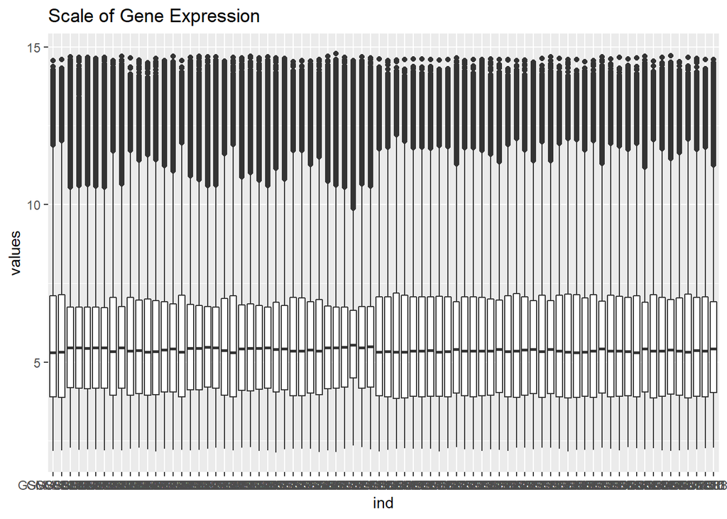

```r
ggplot(data = stack(gse_exprs_df), aes(x = ind, y = values)) +
  geom_boxplot() +
  ggtitle("Scale of Gene Expression")
```

```r
gse_pdata_df$characteristics_ch1.1 <- str_remove(gse_pdata_df$characteristics_ch1.1, pattern = "^sample: ")

table(gse_pdata_df$characteristics_ch1.1)
```

```
##
## normal  tumor
##     39     39
```

## Data Analysis

### Correlation Analysis

The following heat map showcases how the gene expression varies when comparing between samples.

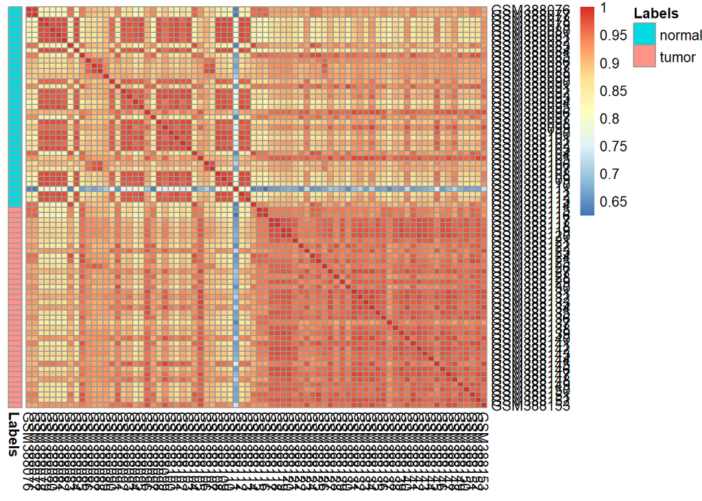

```r
correlation_matrix <- cor(gse_exprs_df, use = "c")

annotation <- data.frame(row.names = rownames(gse_pdata_df),
                         Labels = gse_pdata_df$characteristics_ch1.1)

pheatmap(correlation_matrix,annotation_row = annotation,
         cluster_rows = FALSE, cluster_cols = FALSE)
```

```r
rownames(gse_pdata_df)
```

```
##  [1] "GSM388076" "GSM388077" "GSM388078" "GSM388079" "GSM388080" "GSM388081"
##  [7] "GSM388082" "GSM388083" "GSM388084" "GSM388085" "GSM388086" "GSM388087"
## [13] "GSM388088" "GSM388089" "GSM388090" "GSM388091" "GSM388092" "GSM388093"
## [19] "GSM388094" "GSM388095" "GSM388096" "GSM388097" "GSM388098" "GSM388099"
## [25] "GSM388100" "GSM388101" "GSM388102" "GSM388103" "GSM388104" "GSM388105"
## [31] "GSM388106" "GSM388107" "GSM388108" "GSM388109" "GSM388110" "GSM388111"
## [37] "GSM388112" "GSM388113" "GSM388114" "GSM388115" "GSM388116" "GSM388117"
## [43] "GSM388118" "GSM388119" "GSM388120" "GSM388121" "GSM388122" "GSM388123"
## [49] "GSM388124" "GSM388125" "GSM388126" "GSM388127" "GSM388128" "GSM388129"
## [55] "GSM388130" "GSM388131" "GSM388132" "GSM388133" "GSM388134" "GSM388135"
## [61] "GSM388136" "GSM388137" "GSM388138" "GSM388139" "GSM388140" "GSM388141"
## [67] "GSM388142" "GSM388143" "GSM388144" "GSM388145" "GSM388146" "GSM388147"
## [73] "GSM388148" "GSM388149" "GSM388150" "GSM388151" "GSM388152" "GSM388153"
```

```r
colnames(correlation_matrix)
```

```
##  [1] "GSM388076" "GSM388077" "GSM388078" "GSM388079" "GSM388080" "GSM388081"
##  [7] "GSM388082" "GSM388083" "GSM388084" "GSM388085" "GSM388086" "GSM388087"
## [13] "GSM388088" "GSM388089" "GSM388090" "GSM388091" "GSM388092" "GSM388093"
## [19] "GSM388094" "GSM388095" "GSM388096" "GSM388097" "GSM388098" "GSM388099"
## [25] "GSM388100" "GSM388101" "GSM388102" "GSM388103" "GSM388104" "GSM388105"
## [31] "GSM388106" "GSM388107" "GSM388108" "GSM388109" "GSM388110" "GSM388111"
## [37] "GSM388112" "GSM388113" "GSM388114" "GSM388115" "GSM388116" "GSM388117"
## [43] "GSM388118" "GSM388119" "GSM388120" "GSM388121" "GSM388122" "GSM388123"
## [49] "GSM388124" "GSM388125" "GSM388126" "GSM388127" "GSM388128" "GSM388129"
## [55] "GSM388130" "GSM388131" "GSM388132" "GSM388133" "GSM388134" "GSM388135"
## [61] "GSM388136" "GSM388137" "GSM388138" "GSM388139" "GSM388140" "GSM388141"
## [67] "GSM388142" "GSM388143" "GSM388144" "GSM388145" "GSM388146" "GSM388147"
## [73] "GSM388148" "GSM388149" "GSM388150" "GSM388151" "GSM388152" "GSM388153"
```

### Principal Component Analysis

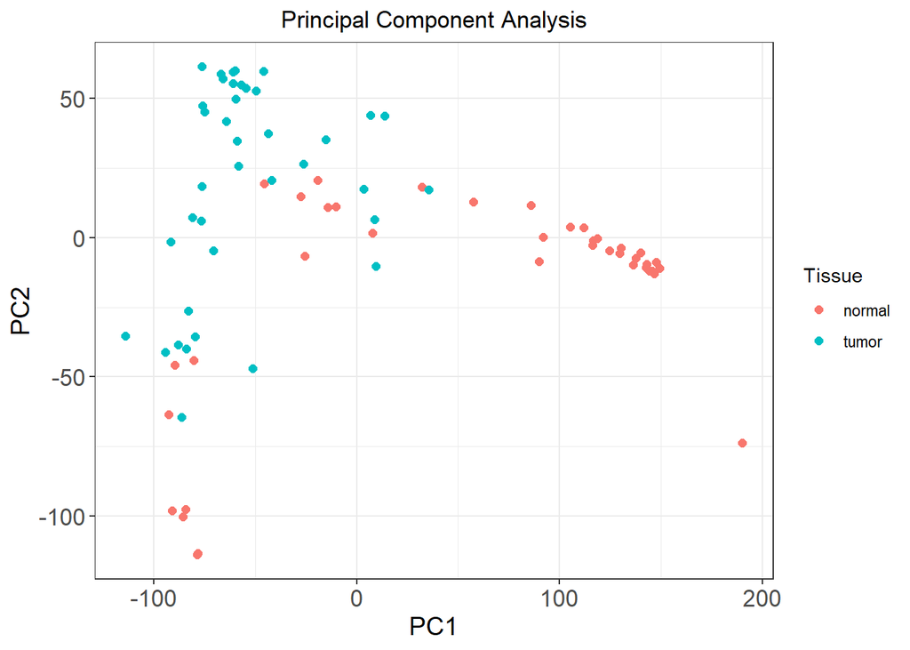

```r
pca <- prcomp(t(gse_exprs_df))

cbind(gse_pdata_df, pca$x) %>%
  ggplot(aes(x = PC1, y=PC2, col=`sample:ch1`)) +
  geom_point(size = 2) +
  ggtitle("Principal Component Analysis") +
  labs(color = "Tissue") +
  theme_bw() +
  theme(plot.title = element_text(hjust = 0.5),
        axis.title = element_text(size = rel(1.3)),
        axis.text = element_text(size = rel(1.2)))
```

### Differential Expression Analysis

```r
design <- model.matrix(~0 + gse_pdata_df$characteristics_ch1.1)
colnames(design) <- c("Normal","Tumor")
design
```

```
##    Normal Tumor
## 1       1     0
## 2       1     0
## 3       1     0
## 4       1     0
## 5       1     0
## 6       1     0
## 7       1     0
## 8       1     0
## 9       1     0
## 10      1     0
## 11      1     0
## 12      1     0
## 13      1     0
## 14      1     0
```

[output cut: 69 more lines]

Keeping only genes expressed above the median levels in 3 or more samples to reduce possibility of false positives.

```r
expression_median <- median(exprs(gse))

expressed <- gse_exprs_df > expression_median

keep <- rowSums(expressed) >= 3

table(keep)
```

```
## keep
## FALSE  TRUE
## 18376 36299
```

Keeping only the genes labeled true

```r
gse_exprs_expressed_df <- gse_exprs_df[keep,]
```

```r
gse_aw <- arrayWeights(gse_exprs_expressed_df,design)
gse_aw
```

```
##          1          2          3          4          5          6          7
## 0.21693927 0.20080297 1.42403857 2.14389364 1.63538010 1.69577116 1.49151788
##          8          9         10         11         12         13         14
## 0.21926871 1.59080456 0.28288268 0.38584172 0.28181520 0.35643028 0.44158925
##         15         16         17         18         19         20         21
## 1.10504689 0.24857860 1.69922375 2.35047566 1.08269029 1.90027679 0.44955428
##         22         23         24         25         26         27         28
## 0.21034640 2.01777941 1.53916379 2.13661832 1.87718959 1.17088655 2.48376278
##         29         30         31         32         33         34         35
## 0.24774310 0.34572790 0.46643036 0.28683657 2.15425803 1.98952687 1.60546666
##         36         37         38         39         40         41         42
## 0.07274545 1.88902618 1.72684853 0.21698628 0.98554003 0.80312698 1.58976007
##         43         44         45         46         47         48         49
## 1.90866090 1.87845169 2.25642535 0.88232225 0.84324996 0.88787800 0.80857384
##         50         51         52         53         54         55         56
## 1.52626193 1.04258421 1.95833294 0.78344977 1.20269280 0.73591937 2.17060452
##         57         58         59         60         61         62         63
## 1.65828231 1.45345426 1.46118635 1.48172144 1.42154124 0.52481404 0.95338486
##         64         65         66         67         68         69         70
## 1.47349841 1.34302686 2.02212878 1.89700525 1.45741568 0.85346901 0.85949237
##         71         72         73         74         75         76         77
## 1.45398980 2.64120708 1.44820032 1.50501433 1.01460773 1.63424799 2.66848829
##         78
## 1.20513880
```

Creating a linear model with the array weights

```r
gse_exprs_expressed_lm <-  lmFit(gse_exprs_expressed_df, design, weights = gse_aw)

head(gse_exprs_expressed_lm$coefficients)
```

```
##        Normal    Tumor
## [1,] 9.522077 9.931770
## [2,] 6.022221 6.417931
## [3,] 6.390274 6.750266
## [4,] 8.376573 7.561677
## [5,] 7.050732 7.754325
## [6,] 5.352315 5.041196
```

Comparing between normal and tumor samples

```r
gse_contrasts <- makeContrasts(Normal - Tumor, levels = design)

gse_contrasts_fit <-contrasts.fit(gse_exprs_expressed_lm,gse_contrasts)
gse_ebayes <- eBayes(gse_contrasts_fit)
```

```r
topTable(gse_ebayes)
```

|  | logFC | AveExpr | t | P.Value | adj.P.Val | B |
| --- | --- | --- | --- | --- | --- | --- |
| 13427 | -5.225593 | 8.577694 | -23.91071 | 5.057798e-38 | 1.835930e-33 | 76.11927 |
| 13417 | -4.267252 | 7.883137 | -23.32883 | 2.810438e-37 | 5.100805e-33 | 74.43639 |
| 13426 | -5.548871 | 8.204443 | -23.02514 | 6.967023e-37 | 8.429865e-33 | 73.54475 |
| 4595 | -3.908467 | 11.390549 | -22.84517 | 1.198181e-36 | 9.958963e-33 | 73.01198 |
| 27624 | -4.764768 | 6.395355 | -22.80042 | 1.371796e-36 | 9.958963e-33 | 72.87899 |
| 7453 | -4.707695 | 7.720621 | -22.45560 | 3.917311e-36 | 2.369908e-32 | 71.84734 |
| 12741 | -4.665831 | 8.763409 | -21.39863 | 1.052676e-34 | 5.458726e-31 | 68.60730 |
| 16142 | -5.051067 | 8.859564 | -21.00862 | 3.651006e-34 | 1.656598e-30 | 67.38133 |
| 7454 | -4.502188 | 10.088465 | -20.90203 | 5.143409e-34 | 1.976967e-30 | 67.04335 |
| 16585 | -4.314745 | 11.061878 | -20.88427 | 5.446340e-34 | 1.976967e-30 | 66.98691 |

```r
summary(decideTests(gse_ebayes))
```

```
##        Normal - Tumor
## Down            17085
## NotSig           5528
## Up              13686
```

```r
table(decideTests(gse_ebayes))
```

```
##
##    -1     0     1
## 17085  5528 13686
```

### Visualization of Selected Gene

Adding gene information to the fitted model.

```r
gse_ebayes$genes <- gse_fdata_df %>%
  select(ID,GB_ACC)

topTable(gse_ebayes)
```

|  | ID | GB_ACC | logFC | AveExpr | t | P.Value | adj.P.Val | B |
| --- | --- | --- | --- | --- | --- | --- | --- | --- |
| 13427 | 203979_at | NM_000784 | -5.225593 | 8.577694 | -23.91071 | 5.057798e-38 | 1.835930e-33 | 76.11927 |
| 13417 | 203969_at | AU157140 | -4.267252 | 7.883137 | -23.32883 | 2.810438e-37 | 5.100805e-33 | 74.43639 |
| 13426 | 203978_at | NM_002484 | -5.548871 | 8.204443 | -23.02514 | 6.967023e-37 | 8.429865e-33 | 73.54475 |
| 4595 | 1559096_x_at | AK095307 | -3.908467 | 11.390549 | -22.84517 | 1.198181e-36 | 9.958963e-33 | 73.01198 |
| 27624 | 218338_at | NM_004426 | -4.764768 | 6.395355 | -22.80042 | 1.371796e-36 | 9.958963e-33 | 72.87899 |
| 7453 | 1564044_at | AK056573 | -4.707695 | 7.720621 | -22.45560 | 3.917311e-36 | 2.369908e-32 | 71.84734 |
| 12741 | 203293_s_at | NM_005570 | -4.665831 | 8.763409 | -21.39863 | 1.052676e-34 | 5.458726e-31 | 68.60730 |
| 16142 | 206695_x_at | NM_003423 | -5.051067 | 8.859564 | -21.00862 | 3.651006e-34 | 1.656598e-30 | 67.38133 |
| 7454 | 1564049_at | BC043370 | -4.502188 | 10.088465 | -20.90203 | 5.143409e-34 | 1.976967e-30 | 67.04335 |
| 16585 | 207138_at | NM_005392 | -4.314745 | 11.061878 | -20.88427 | 5.446340e-34 | 1.976967e-30 | 66.98691 |

Volcano plot

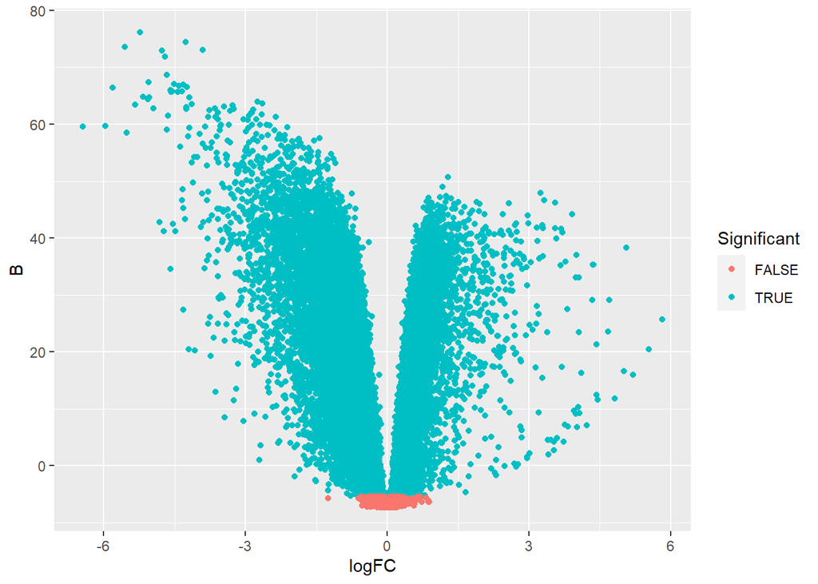

```r
results <- topTable(gse_ebayes, coef = 1, number = Inf) %>%
  mutate(Significant = P.Value < 0.05, abs(logFC) > 1)
results%>%
ggplot(aes(x = logFC, y = B, col = Significant)) +
  geom_point()
```

### Investigating the Top Ranked Gene

From our analysis, we know the top ranked gene is NM_000784.

```r
filter(results, GB_ACC == "NM_000784")
```

| ID | GB_ACC | logFC | AveExpr | t | P.Value | adj.P.Val | B | Significant | abs(logFC) > 1 |
| --- | --- | --- | --- | --- | --- | --- | --- | --- | --- |
| 203979_at | NM_000784 | -5.225593 | 8.577694 | -23.91071 | 5.057798e-38 | 1.83593e-33 | 76.11927 | TRUE | TRUE |

## References

[1]

R. H. Hruban and N. V. Adsay, “Molecular classification of neoplasms of the pancreas,” *Human pathology*, vol. 40, no. 5, pp. 612–623, 2009.

[2]

L. Badea and I. Popescu, “Whole-Tissue Gene Expression Study of Pancreatic Ductal Adenocarcinoma,” *Gene Expression Omnibus*. Mar. 2009. Available: https://www.ncbi.nlm.nih.gov/geo/query/acc.cgi?acc=gse15471

[3]

H. Wickham *et al.*, “Welcome to the tidyverse,” *Journal of Open Source Software*, vol. 4, no. 43, p. 1686, 2019, doi: 10.21105/joss.01686.

[4]

R. Kolde, *Pheatmap: Pretty heatmaps*. 2019. Available: https://CRAN.R-project.org/package=pheatmap

[5]

S. Davis and P. Meltzer, “GEOquery: A bridge between the gene expression omnibus (GEO) and BioConductor,” *Bioinformatics*, vol. 14, pp. 1846–1847, 2007.

[6]

M. E. Ritchie *et al.*, “limma powers differential expression analyses for RNA-sequencing and microarray studies,” *Nucleic Acids Research*, vol. 43, no. 7, p. e47, 2015, doi: 10.1093/nar/gkv007.